# act_report

## Report: act_report

### Project Insights

##### Introduction

This Twitter account called WeRateDogs that provides ratings for people's pets (dogs) in exchange for a witty remark about the dog. Most of the time, ten is used as the denominator in these ratings. Now the numerator is interesting, the value is greater than ten, as shown by the numbers 10/10 and 11/10, as well as twelve ten, thirteen ten, and so on. WeRateDogs has gained extensive international media coverage as a result of its more than 4 million followers.

Twitter's developer API has made it feasible to access information about dog ratings posted on tweeter by weratedos. It is possible to combine data from a neural network system that is capable of predicting different dog breeds with Twitter JSON data to generate a highly effective combination. This huge amount of data may be acquired, analyzed, cleansed, and integrated with other data using data wrangling techniques to provide insight into the data's relationship with other data.

### Wrangling The Data

In order to do my analysis properly, I had to wrangle to data so that it is goos shape for the work. I assessed the data both visually and programatically for both quality and tidiness issues. The quality of data is determined mainly by looking at several aspects or dimensions to ensure that it is complete, valid, accurate and consistent. After cleaning many of the issues found during the assessment, there were about 2080 tweets with good quality data.

### Insights

##### 12 is the most common Rating Numerator

I really wanted to know how often a particullar rating denomitor appeared. the rating 12 came out top. Although I expected a higher number, 12 appeared as a numerator four hundred and eighty six times

##### Pupper appears many more times than any other dog stage

Most of the dogs that were rated were in the pupper stage which makes sense to me because my dog is inthe stage too and most people love puppers.

##### Lucy and Charlie are Favorite Names

These names both appear the most in our data. So it wil be fair to sat that they are favorite names.

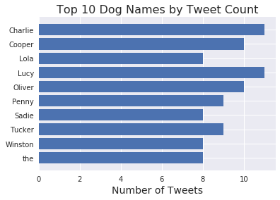

This plot shows the top 10 dog names. these dog manes that appear most in the tweets